# NASA TURBOFAN DATASET

```python
import pandas as pd
import numpy as np
import matplotlib.pyplot as plt
import seaborn as sns
from sklearn.ensemble import RandomForestRegressor
import sklearn
from sklearn.metrics import mean_squared_error, r2_score
import os
from sklearn.model_selection import train_test_split
from sklearn.preprocessing import StandardScaler
import random
import warnings
np.random.seed(34)
warnings.filterwarnings('ignore')
```

```python
index_names = ['unit_number', 'time_cycles']
setting_names = ['setting_1', 'setting_2', 'setting_3']
sensor_names = ['s_{}'.format(i+1) for i in range(0,21)]
col_names = index_names + setting_names + sensor_names
```

```python
df_train= pd.read_csv(r"C:\Users\LENOVO\Downloads\archive (2)\CMaps\train_FD001.txt",sep='\s',header=None,names=col_names,index_col=False)
df_test= pd.read_csv(r"C:\Users\LENOVO\Downloads\archive (2)\CMaps\test_FD001.txt",sep='\s',header=None,names=col_names,index_col=False)
df_y= pd.read_csv(r"C:\Users\LENOVO\Downloads\archive (2)\CMaps\RUL_FD001.txt",sep='\s',header=None,names=col_names,index_col=False)
```

```python
df_train.shape
```

```
(20631, 26)
```

```python
df_train.head(5)
```

|  | unit_number | time_cycles | setting_1 | setting_2 | setting_3 | s_1 | s_2 | s_3 | s_4 | s_5 | ... | s_12 | s_13 | s_14 | s_15 | s_16 | s_17 | s_18 | s_19 | s_20 | s_21 |
| --- | --- | --- | --- | --- | --- | --- | --- | --- | --- | --- | --- | --- | --- | --- | --- | --- | --- | --- | --- | --- | --- |
| 0 | 1 | 1 | -0.0007 | -0.0004 | 100.0 | 518.67 | 641.82 | 1589.70 | 1400.60 | 14.62 | ... | 521.66 | 2388.02 | 8138.62 | 8.4195 | 0.03 | 392 | 2388 | 100.0 | 39.06 | 23.4190 |
| 1 | 1 | 2 | 0.0019 | -0.0003 | 100.0 | 518.67 | 642.15 | 1591.82 | 1403.14 | 14.62 | ... | 522.28 | 2388.07 | 8131.49 | 8.4318 | 0.03 | 392 | 2388 | 100.0 | 39.00 | 23.4236 |
| 2 | 1 | 3 | -0.0043 | 0.0003 | 100.0 | 518.67 | 642.35 | 1587.99 | 1404.20 | 14.62 | ... | 522.42 | 2388.03 | 8133.23 | 8.4178 | 0.03 | 390 | 2388 | 100.0 | 38.95 | 23.3442 |
| 3 | 1 | 4 | 0.0007 | 0.0000 | 100.0 | 518.67 | 642.35 | 1582.79 | 1401.87 | 14.62 | ... | 522.86 | 2388.08 | 8133.83 | 8.3682 | 0.03 | 392 | 2388 | 100.0 | 38.88 | 23.3739 |
| 4 | 1 | 5 | -0.0019 | -0.0002 | 100.0 | 518.67 | 642.37 | 1582.85 | 1406.22 | 14.62 | ... | 522.19 | 2388.04 | 8133.80 | 8.4294 | 0.03 | 393 | 2388 | 100.0 | 38.90 | 23.4044 |

5 rows × 26 columns

```python
df_train.isna().sum()
```

```
unit_number    0
time_cycles    0
setting_1      0
setting_2      0
setting_3      0
s_1            0
s_2            0
s_3            0
s_4            0
s_5            0
s_6            0
s_7            0
s_8            0
s_9            0
s_10           0
s_11           0
s_12           0
s_13           0
s_14           0
s_15           0
s_16           0
s_17           0
s_18           0
s_19           0
s_20           0
s_21           0
dtype: int64
```

```python
train= df_train.copy()
test= df_test.copy()
```

```python
train.head(2)
```

|  | unit_number | time_cycles | setting_1 | setting_2 | setting_3 | s_1 | s_2 | s_3 | s_4 | s_5 | ... | s_12 | s_13 | s_14 | s_15 | s_16 | s_17 | s_18 | s_19 | s_20 | s_21 |
| --- | --- | --- | --- | --- | --- | --- | --- | --- | --- | --- | --- | --- | --- | --- | --- | --- | --- | --- | --- | --- | --- |
| 0 | 1 | 1 | -0.0007 | -0.0004 | 100.0 | 518.67 | 641.82 | 1589.70 | 1400.60 | 14.62 | ... | 521.66 | 2388.02 | 8138.62 | 8.4195 | 0.03 | 392 | 2388 | 100.0 | 39.06 | 23.4190 |
| 1 | 1 | 2 | 0.0019 | -0.0003 | 100.0 | 518.67 | 642.15 | 1591.82 | 1403.14 | 14.62 | ... | 522.28 | 2388.07 | 8131.49 | 8.4318 | 0.03 | 392 | 2388 | 100.0 | 39.00 | 23.4236 |

2 rows × 26 columns

```python
train.iloc[:,0:2].describe() #.transpose()
```

|  | unit_number | time_cycles |
| --- | --- | --- |
| count | 20631.000000 | 20631.000000 |
| mean | 51.506568 | 108.807862 |
| std | 29.227633 | 68.880990 |
| min | 1.000000 | 1.000000 |
| 25% | 26.000000 | 52.000000 |
| 50% | 52.000000 | 104.000000 |
| 75% | 77.000000 | 156.000000 |
| max | 100.000000 | 362.000000 |

When we inspect the descriptive statistics of unit_nr we can see the dataset has a total of 20631 rows, unit numbers start at 1 and end at 100 as expected. What’s interesting, is that the mean and quantiles don’t align neatly with the descriptive statistics of a vector from 1–100, this can be explained due to each unit having different max time_cycles and thus a different number of rows. When inspecting the max time_cycles you can see the engine which failed the earliest did so after 128 cycles, whereas the engine which operated the longest broke down after 362 cycles. The average engine breaks between 199 and 206 cycles, however the standard deviation of 46 cycles is rather big. We’ll visualize this further down below to get an even better understanding.

```python
train.loc[:,'s_1':].describe().transpose()
```

|  | count | mean | std | min | 25% | 50% | 75% | max |
| --- | --- | --- | --- | --- | --- | --- | --- | --- |
| s_1 | 20631.0 | 518.670000 | 6.537152e-11 | 518.6700 | 518.6700 | 518.6700 | 518.6700 | 518.6700 |
| s_2 | 20631.0 | 642.680934 | 5.000533e-01 | 641.2100 | 642.3250 | 642.6400 | 643.0000 | 644.5300 |
| s_3 | 20631.0 | 1590.523119 | 6.131150e+00 | 1571.0400 | 1586.2600 | 1590.1000 | 1594.3800 | 1616.9100 |
| s_4 | 20631.0 | 1408.933782 | 9.000605e+00 | 1382.2500 | 1402.3600 | 1408.0400 | 1414.5550 | 1441.4900 |
| s_5 | 20631.0 | 14.620000 | 3.394700e-12 | 14.6200 | 14.6200 | 14.6200 | 14.6200 | 14.6200 |
| s_6 | 20631.0 | 21.609803 | 1.388985e-03 | 21.6000 | 21.6100 | 21.6100 | 21.6100 | 21.6100 |
| s_7 | 20631.0 | 553.367711 | 8.850923e-01 | 549.8500 | 552.8100 | 553.4400 | 554.0100 | 556.0600 |
| s_8 | 20631.0 | 2388.096652 | 7.098548e-02 | 2387.9000 | 2388.0500 | 2388.0900 | 2388.1400 | 2388.5600 |
| s_9 | 20631.0 | 9065.242941 | 2.208288e+01 | 9021.7300 | 9053.1000 | 9060.6600 | 9069.4200 | 9244.5900 |
| s_10 | 20631.0 | 1.300000 | 4.660829e-13 | 1.3000 | 1.3000 | 1.3000 | 1.3000 | 1.3000 |
| s_11 | 20631.0 | 47.541168 | 2.670874e-01 | 46.8500 | 47.3500 | 47.5100 | 47.7000 | 48.5300 |
| s_12 | 20631.0 | 521.413470 | 7.375534e-01 | 518.6900 | 520.9600 | 521.4800 | 521.9500 | 523.3800 |
| s_13 | 20631.0 | 2388.096152 | 7.191892e-02 | 2387.8800 | 2388.0400 | 2388.0900 | 2388.1400 | 2388.5600 |
| s_14 | 20631.0 | 8143.752722 | 1.907618e+01 | 8099.9400 | 8133.2450 | 8140.5400 | 8148.3100 | 8293.7200 |
| s_15 | 20631.0 | 8.442146 | 3.750504e-02 | 8.3249 | 8.4149 | 8.4389 | 8.4656 | 8.5848 |
| s_16 | 20631.0 | 0.030000 | 1.556432e-14 | 0.0300 | 0.0300 | 0.0300 | 0.0300 | 0.0300 |
| s_17 | 20631.0 | 393.210654 | 1.548763e+00 | 388.0000 | 392.0000 | 393.0000 | 394.0000 | 400.0000 |
| s_18 | 20631.0 | 2388.000000 | 0.000000e+00 | 2388.0000 | 2388.0000 | 2388.0000 | 2388.0000 | 2388.0000 |
| s_19 | 20631.0 | 100.000000 | 0.000000e+00 | 100.0000 | 100.0000 | 100.0000 | 100.0000 | 100.0000 |
| s_20 | 20631.0 | 38.816271 | 1.807464e-01 | 38.1400 | 38.7000 | 38.8300 | 38.9500 | 39.4300 |
| s_21 | 20631.0 | 23.289705 | 1.082509e-01 | 22.8942 | 23.2218 | 23.2979 | 23.3668 | 23.6184 |

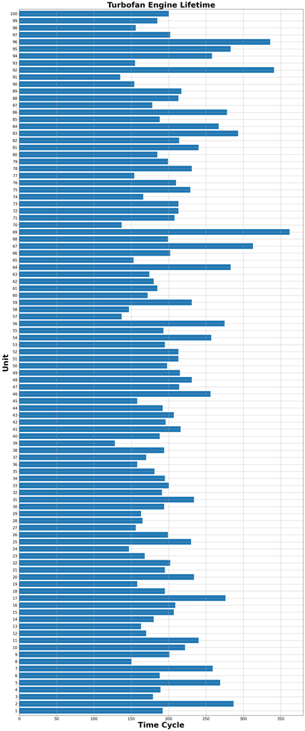

```python
max_time_cycles=train.groupby('unit_number')['time_cycles'].max()
plt.figure(figsize=(20,50))
max_time_cycles.plot(kind='barh',width=0.8,align='center')
plt.title('Turbofan Engine Lifetime',fontweight='bold',size=30)
plt.xlabel('Time Cycle',fontweight='bold',size=30)
plt.xticks(size=15)
plt.ylabel('Unit',fontweight='bold',size=30)
plt.yticks(size=15)
plt.grid(True)
plt.show()
```

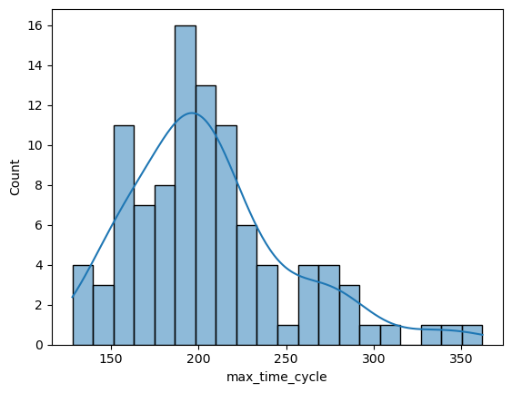

```python
sns.histplot(data=max_time_cycles,bins=20,kde=True)
plt.xlabel('max_time_cycle')
```

```python
def add_rul_col(df):
    max_time_cycles= df.groupby(by="unit_number")['time_cycles'].max()
    merged= df.merge(max_time_cycles.to_frame(name='max_time_cycles'),left_on='unit_number',right_index=True)
    merged['RUL'] = merged['max_time_cycles'] - merged['time_cycles']
    merged= merged.drop("max_time_cycles",axis=1)
    return merged
```

```python
train=add_rul_col(train)
```

```python
train.head(5)
```

|  | unit_number | time_cycles | setting_1 | setting_2 | setting_3 | s_1 | s_2 | s_3 | s_4 | s_5 | ... | s_13 | s_14 | s_15 | s_16 | s_17 | s_18 | s_19 | s_20 | s_21 | RUL |
| --- | --- | --- | --- | --- | --- | --- | --- | --- | --- | --- | --- | --- | --- | --- | --- | --- | --- | --- | --- | --- | --- |
| 0 | 1 | 1 | -0.0007 | -0.0004 | 100.0 | 518.67 | 641.82 | 1589.70 | 1400.60 | 14.62 | ... | 2388.02 | 8138.62 | 8.4195 | 0.03 | 392 | 2388 | 100.0 | 39.06 | 23.4190 | 191 |
| 1 | 1 | 2 | 0.0019 | -0.0003 | 100.0 | 518.67 | 642.15 | 1591.82 | 1403.14 | 14.62 | ... | 2388.07 | 8131.49 | 8.4318 | 0.03 | 392 | 2388 | 100.0 | 39.00 | 23.4236 | 190 |
| 2 | 1 | 3 | -0.0043 | 0.0003 | 100.0 | 518.67 | 642.35 | 1587.99 | 1404.20 | 14.62 | ... | 2388.03 | 8133.23 | 8.4178 | 0.03 | 390 | 2388 | 100.0 | 38.95 | 23.3442 | 189 |
| 3 | 1 | 4 | 0.0007 | 0.0000 | 100.0 | 518.67 | 642.35 | 1582.79 | 1401.87 | 14.62 | ... | 2388.08 | 8133.83 | 8.3682 | 0.03 | 392 | 2388 | 100.0 | 38.88 | 23.3739 | 188 |
| 4 | 1 | 5 | -0.0019 | -0.0002 | 100.0 | 518.67 | 642.37 | 1582.85 | 1406.22 | 14.62 | ... | 2388.04 | 8133.80 | 8.4294 | 0.03 | 393 | 2388 | 100.0 | 38.90 | 23.4044 | 187 |

5 rows × 27 columns

```python
train[['unit_number','RUL']]
```

|  | unit_number | RUL |
| --- | --- | --- |
| 0 | 1 | 191 |
| 1 | 1 | 190 |
| 2 | 1 | 189 |
| 3 | 1 | 188 |
| 4 | 1 | 187 |
| ... | ... | ... |
| 20626 | 100 | 4 |
| 20627 | 100 | 3 |
| 20628 | 100 | 2 |
| 20629 | 100 | 1 |
| 20630 | 100 | 0 |

20631 rows × 2 columns

```python
max_rul=train.groupby('unit_number').max()
max_rul.head()
```

| unit_number | time_cycles | setting_1 | setting_2 | setting_3 | s_1 | s_2 | s_3 | s_4 | s_5 | s_6 | ... | s_13 | s_14 | s_15 | s_16 | s_17 | s_18 | s_19 | s_20 | s_21 | RUL |
| --- | --- | --- | --- | --- | --- | --- | --- | --- | --- | --- | --- | --- | --- | --- | --- | --- | --- | --- | --- | --- | --- |
| 1 | 192 | 0.0047 | 0.0005 | 100.0 | 518.67 | 644.21 | 1605.44 | 1432.52 | 14.62 | 21.61 | ... | 2388.35 | 8140.58 | 8.5227 | 0.03 | 398 | 2388 | 100.0 | 39.18 | 23.4999 | 191 |
| 2 | 287 | 0.0076 | 0.0006 | 100.0 | 518.67 | 643.94 | 1610.10 | 1431.17 | 14.62 | 21.61 | ... | 2388.26 | 8175.57 | 8.5377 | 0.03 | 398 | 2388 | 100.0 | 39.24 | 23.6005 | 286 |
| 3 | 179 | 0.0058 | 0.0005 | 100.0 | 518.67 | 643.93 | 1606.50 | 1438.51 | 14.62 | 21.61 | ... | 2388.20 | 8255.34 | 8.5363 | 0.03 | 399 | 2388 | 100.0 | 39.23 | 23.5181 | 178 |
| 4 | 189 | 0.0059 | 0.0006 | 100.0 | 518.67 | 644.53 | 1612.11 | 1434.12 | 14.62 | 21.61 | ... | 2388.17 | 8259.42 | 8.5462 | 0.03 | 399 | 2388 | 100.0 | 39.21 | 23.5074 | 188 |
| 5 | 269 | 0.0055 | 0.0005 | 100.0 | 518.67 | 644.02 | 1609.41 | 1434.59 | 14.62 | 21.61 | ... | 2388.23 | 8215.19 | 8.5410 | 0.03 | 398 | 2388 | 100.0 | 39.29 | 23.5503 | 268 |

5 rows × 26 columns

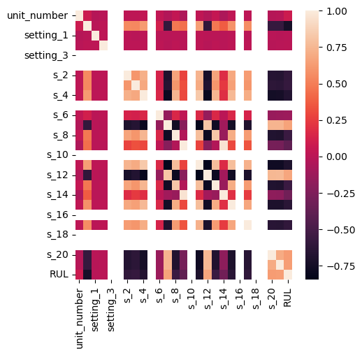

```python
corr= train.corr()
plt.figure(figsize=(5,5))
sns.heatmap(corr)
```

```python
Sensor_dictionary={}

dict_list=[ "(Fan inlet temperature) (◦R)",
"(LPC outlet temperature) (◦R)",
"(HPC outlet temperature) (◦R)",
"(LPT outlet temperature) (◦R)",
"(Fan inlet Pressure) (psia)",
"(bypass-duct pressure) (psia)",
"(HPC outlet pressure) (psia)",
"(Physical fan speed) (rpm)",
"(Physical core speed) (rpm)",
"(Engine pressure ratio(P50/P2)",
"(HPC outlet Static pressure) (psia)",
"(Ratio of fuel flow to Ps30) (pps/psia)",
"(Corrected fan speed) (rpm)",
"(Corrected core speed) (rpm)",
"(Bypass Ratio) ",
"(Burner fuel-air ratio)",
"(Bleed Enthalpy)",
"(Required fan speed)",
"(Required fan conversion speed)",
"(High-pressure turbines Cool air flow)",
"(Low-pressure turbines Cool air flow)" ]

i=1

for x in dict_list:
    Sensor_dictionary['s_'+str(i)]=x
    i+=1
Sensor_dictionary
```

```
{'s_1': '(Fan inlet temperature) (◦R)',
 's_2': '(LPC outlet temperature) (◦R)',
 's_3': '(HPC outlet temperature) (◦R)',
 's_4': '(LPT outlet temperature) (◦R)',
 's_5': '(Fan inlet Pressure) (psia)',
 's_6': '(bypass-duct pressure) (psia)',
 's_7': '(HPC outlet pressure) (psia)',
 's_8': '(Physical fan speed) (rpm)',
 's_9': '(Physical core speed) (rpm)',
 's_10': '(Engine pressure ratio(P50/P2)',
 's_11': '(HPC outlet Static pressure) (psia)',
 's_12': '(Ratio of fuel flow to Ps30) (pps/psia)',
 's_13': '(Corrected fan speed) (rpm)',
 's_14': '(Corrected core speed) (rpm)',
 's_15': '(Bypass Ratio) ',
 's_16': '(Burner fuel-air ratio)',
 's_17': '(Bleed Enthalpy)',
 's_18': '(Required fan speed)',
 's_19': '(Required fan conversion speed)',
 's_20': '(High-pressure turbines Cool air flow)',
 's_21': '(Low-pressure turbines Cool air flow)'}
```

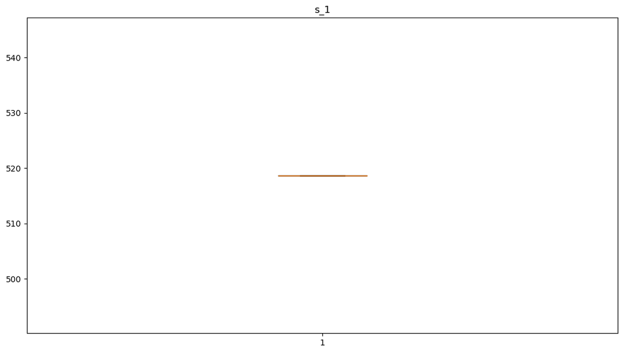

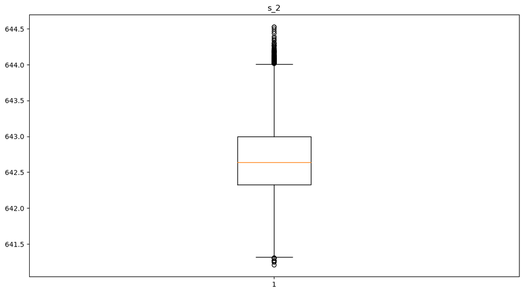

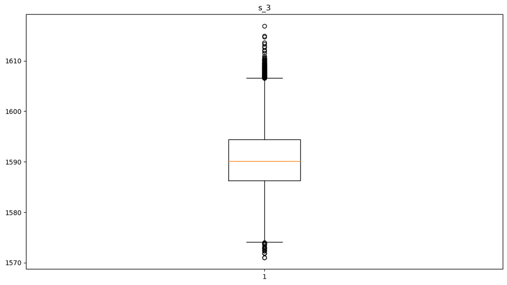

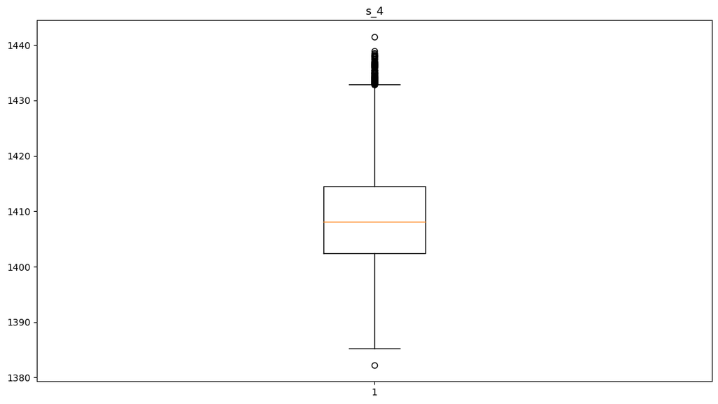

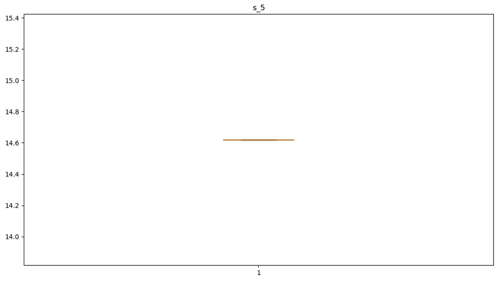

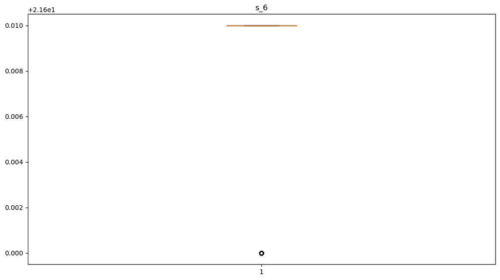

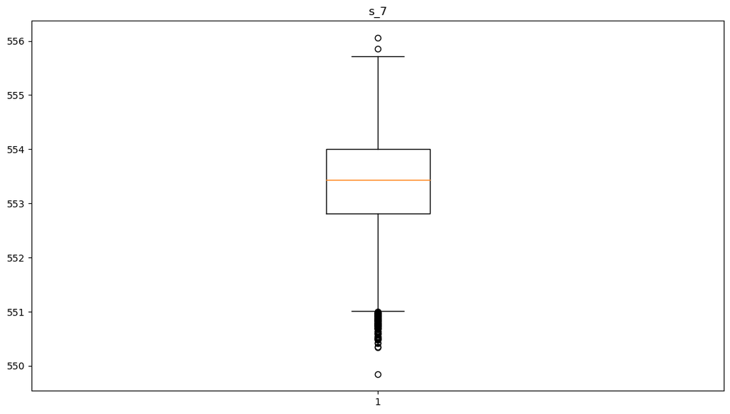

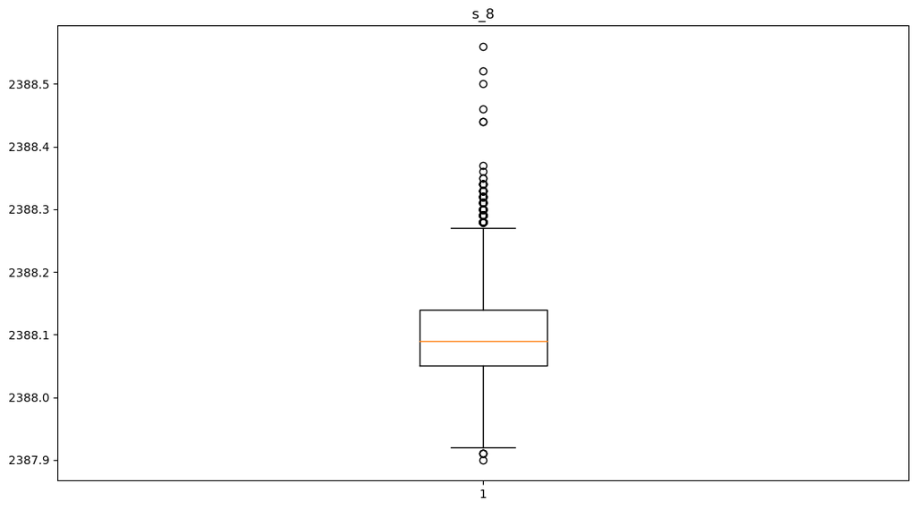

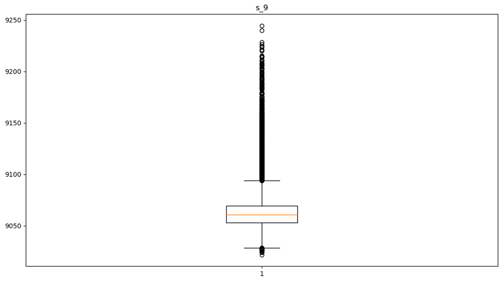

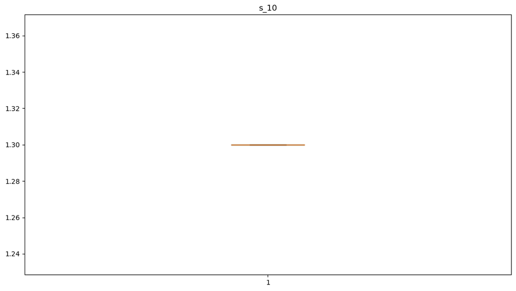

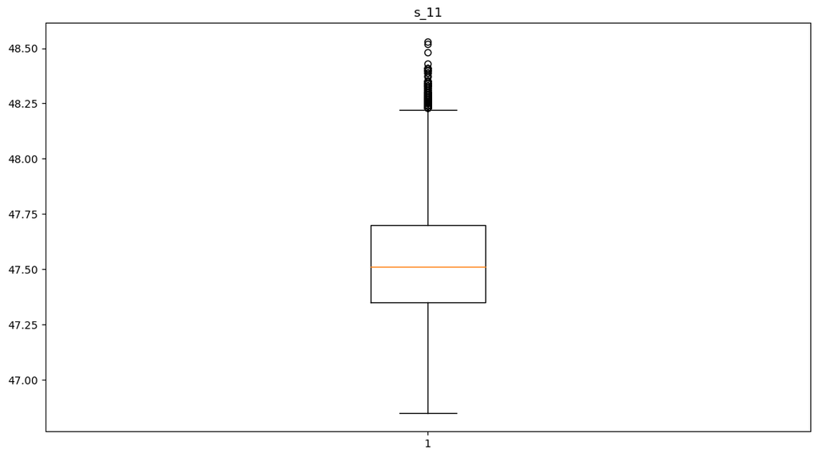

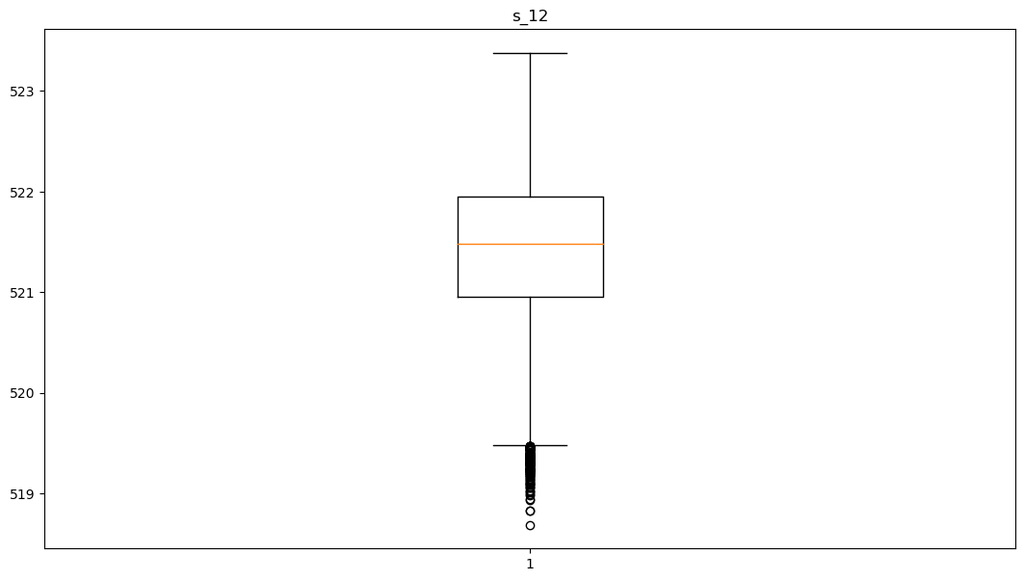

[9 more figures not shown]

```python
for x in sensor_names:
    plt.figure(figsize=(13,7))
    plt.boxplot(train[x])
    plt.title(x)
    plt.show()
```

```python
train.loc[:,'s_1':].describe().transpose()
```

|  | count | mean | std | min | 25% | 50% | 75% | max |
| --- | --- | --- | --- | --- | --- | --- | --- | --- |
| s_1 | 20631.0 | 518.670000 | 6.537152e-11 | 518.6700 | 518.6700 | 518.6700 | 518.6700 | 518.6700 |
| s_2 | 20631.0 | 642.680934 | 5.000533e-01 | 641.2100 | 642.3250 | 642.6400 | 643.0000 | 644.5300 |
| s_3 | 20631.0 | 1590.523119 | 6.131150e+00 | 1571.0400 | 1586.2600 | 1590.1000 | 1594.3800 | 1616.9100 |
| s_4 | 20631.0 | 1408.933782 | 9.000605e+00 | 1382.2500 | 1402.3600 | 1408.0400 | 1414.5550 | 1441.4900 |
| s_5 | 20631.0 | 14.620000 | 3.394700e-12 | 14.6200 | 14.6200 | 14.6200 | 14.6200 | 14.6200 |
| s_6 | 20631.0 | 21.609803 | 1.388985e-03 | 21.6000 | 21.6100 | 21.6100 | 21.6100 | 21.6100 |
| s_7 | 20631.0 | 553.367711 | 8.850923e-01 | 549.8500 | 552.8100 | 553.4400 | 554.0100 | 556.0600 |
| s_8 | 20631.0 | 2388.096652 | 7.098548e-02 | 2387.9000 | 2388.0500 | 2388.0900 | 2388.1400 | 2388.5600 |
| s_9 | 20631.0 | 9065.242941 | 2.208288e+01 | 9021.7300 | 9053.1000 | 9060.6600 | 9069.4200 | 9244.5900 |
| s_10 | 20631.0 | 1.300000 | 4.660829e-13 | 1.3000 | 1.3000 | 1.3000 | 1.3000 | 1.3000 |
| s_11 | 20631.0 | 47.541168 | 2.670874e-01 | 46.8500 | 47.3500 | 47.5100 | 47.7000 | 48.5300 |
| s_12 | 20631.0 | 521.413470 | 7.375534e-01 | 518.6900 | 520.9600 | 521.4800 | 521.9500 | 523.3800 |
| s_13 | 20631.0 | 2388.096152 | 7.191892e-02 | 2387.8800 | 2388.0400 | 2388.0900 | 2388.1400 | 2388.5600 |
| s_14 | 20631.0 | 8143.752722 | 1.907618e+01 | 8099.9400 | 8133.2450 | 8140.5400 | 8148.3100 | 8293.7200 |
| s_15 | 20631.0 | 8.442146 | 3.750504e-02 | 8.3249 | 8.4149 | 8.4389 | 8.4656 | 8.5848 |
| s_16 | 20631.0 | 0.030000 | 1.556432e-14 | 0.0300 | 0.0300 | 0.0300 | 0.0300 | 0.0300 |
| s_17 | 20631.0 | 393.210654 | 1.548763e+00 | 388.0000 | 392.0000 | 393.0000 | 394.0000 | 400.0000 |
| s_18 | 20631.0 | 2388.000000 | 0.000000e+00 | 2388.0000 | 2388.0000 | 2388.0000 | 2388.0000 | 2388.0000 |
| s_19 | 20631.0 | 100.000000 | 0.000000e+00 | 100.0000 | 100.0000 | 100.0000 | 100.0000 | 100.0000 |
| s_20 | 20631.0 | 38.816271 | 1.807464e-01 | 38.1400 | 38.7000 | 38.8300 | 38.9500 | 39.4300 |
| s_21 | 20631.0 | 23.289705 | 1.082509e-01 | 22.8942 | 23.2218 | 23.2979 | 23.3668 | 23.6184 |
| RUL | 20631.0 | 107.807862 | 6.888099e+01 | 0.0000 | 51.0000 | 103.0000 | 155.0000 | 361.0000 |

```python
x= train.iloc[:,0:-1]
y= train['RUL']
x_train,x_test,y_train,y_test= train_test_split(x,y,test_size=0.3,random_state=42)
print("x_Train data size is ",x_train.shape)
print("y_Train data size is ",y_train.shape)
print("x_Test data size is ",x_test.shape)
print("y_Test data size is ",y_test.shape)
```

```
x_Train data size is  (14441, 26)
y_Train data size is  (14441,)
x_Test data size is  (6190, 26)
y_Test data size is  (6190,)
```

```python
from sklearn.preprocessing import MinMaxScaler
scler= MinMaxScaler()
x_train= scler.fit_transform(x_train)
x_test= scler.fit_transform(x_test)
```

```python
from sklearn.linear_model import LinearRegression
from sklearn.metrics import r2_score, mean_squared_error


model_logit= LinearRegression()
model_logit.fit(x_train,y_train)
pv= model_logit.predict(x_test)
print("r2 score for mode is ", r2_score(y_test,pv))
print("r2 score for mode is ", mean_squared_error(y_test,pv))
```

```
r2 score for mode is  0.64495060943609
r2 score for mode is  1626.2592708300174
```

```python
l=['s_1','s_6','s_10','s_16','s_18','s_19']
df2= train.drop(l,axis=1)


x2= df2.iloc[:,0:-1]
y2= df2['RUL']
x2_train,x2_test,y2_train,y2_test= train_test_split(x,y,test_size=0.3,random_state=42)
print("x_Train data size is ",x2_train.shape)
print("y_Train data size is ",y2_train.shape)
print("x_Test data size is ",x2_test.shape)
print("y_Test data size is ",y2_test.shape)


x2_train= scler.fit_transform(x2_train)
x2_test= scler.fit_transform(x2_test)



model_logit2= LinearRegression()
model_logit2.fit(x2_train,y2_train)
pv= model_logit.predict(x2_test)
print("r2 score for mode is ", r2_score(y2_test,pv))
print("r2 score for mode is ", mean_squared_error(y2_test,pv))
```

```
x_Train data size is  (14441, 26)
y_Train data size is  (14441,)
x_Test data size is  (6190, 26)
y_Test data size is  (6190,)
r2 score for mode is  0.64495060943609
r2 score for mode is  1626.2592708300174
```